# Question

Al momento de realizar un viaje por carretera, un repartidor registró cuidadosamente los siguientes parámetros durante su recorrido:

| Tiempo (horas) | Costo del viaje (miles de pesos) | Combustible disponible (litros) | Distancia recorrida (kilómetros) |
| --- | --- | --- | --- |
| 0 | 0 | 46 | 0 |
| 2 | 24 | 38 | 16 |
| 4 | 46 | 25 | 36 |
| 6 | 69 | 12 | 41 |
| 8 | 98 | 5 | 59 |

Después de analizar los datos del viaje, se generaron diversas interpretaciones gráficas. ¿Cuál de las siguientes gráficas representa CORRECTAMENTE la relación entre la distancia recorrida y el costo del viaje en función del tiempo, considerando las características físicas del desplazamiento y el consumo esperado del vehículo?

## Answerlist

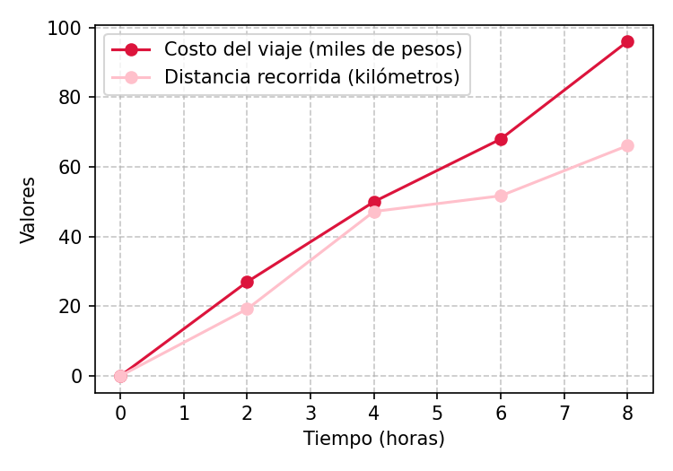

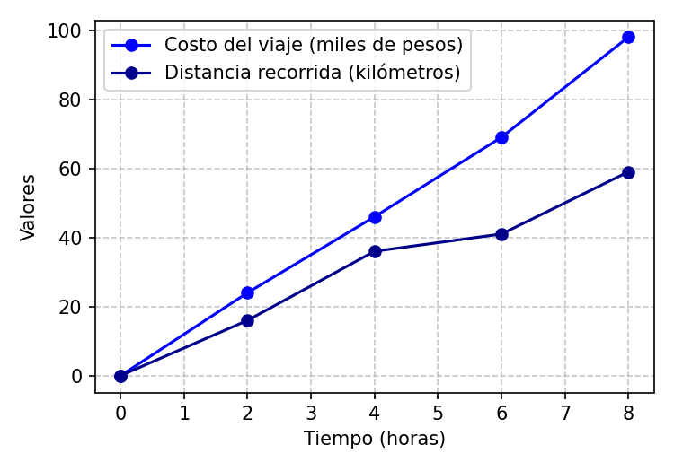

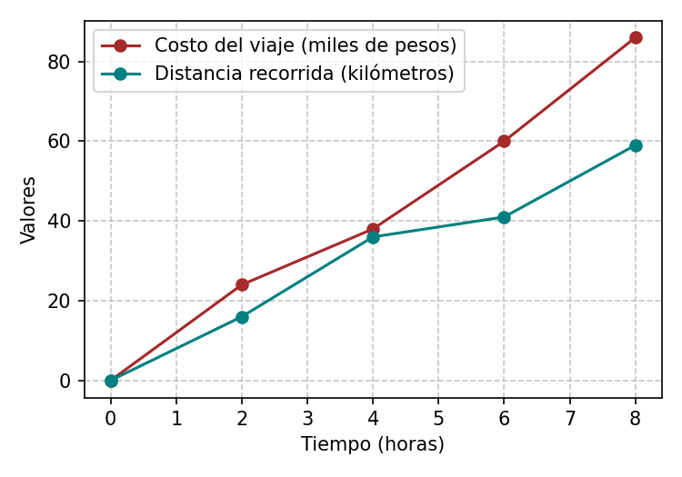

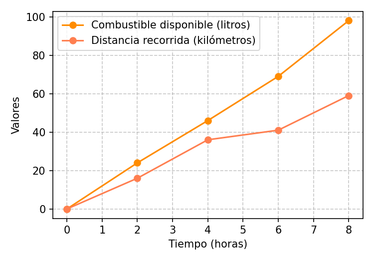

# Solution

Para determinar la gráfica correcta, es necesario analizar las relaciones físicas y matemáticas que gobiernan el movimiento del vehículo y el costo asociado al viaje:

La gráfica correcta

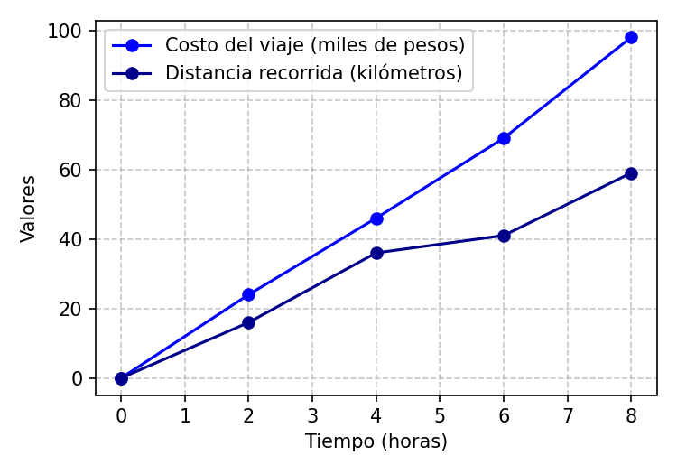

- La tendencia creciente del costo desde un valor inicial mínimo (cero)
- La tendencia creciente de la distancia desde un valor inicial cero
- Una relación consistente con el modelo económico de un viaje
- Las etiquetas correctas para cada variable representada

Las demás opciones presentan anomalías económicamente inconsistentes o errores en el etiquetado. En particular, una de las opciones muestra exactamente los mismos datos que la gráfica correcta, pero con la etiqueta “Combustible disponible” en lugar de “Costo del viaje”, lo que es incorrecto ya que el comportamiento creciente corresponde al costo acumulado del viaje, no al combustible que disminuye durante el recorrido.

## Answerlist

- Falso
- Verdadero
- Falso
- Falso

# Meta-information

exname: Interpretación avanzada de gráficas de viaje extype: schoice exsolution: 0100 exshuffle: TRUE exsection: Interpretación de gráficas